# 10_Emission_Analysis

Lolita Muller

m.lolita@cgiar.org

2025-09-26

## Introduction

This notebook provides the analytical workflow used to quantify how observed **diet shifts** alter **enteric methane (CH₄) emission intensity (EI)** across **cattle, sheep, and goats** within African livestock systems.  
The analyses draw on the **ERA v1.0.1** georeferenced meta-dataset, which compiles more than 500 feeding trials conducted from 1934 to 2024 across the continent. The overarching objective is to link **diet composition**, **feed intake**, and **animal performance** with **Tier-2–based CH₄ emission estimates**, and to identify feeding practices that consistently reduce emission intensity while maintaining or improving productivity.

The workflow harmonizes heterogeneous datasets through a reproducible multi-stage pipeline that integrates:

- **Gross energy (GE) reconstruction:** a five-step cascade combining ERA records, Feedipedia tabulated values, ILRI feed composition libraries, and the Weiss & Tebbe (2019) empirical equation.
- **Methane estimation:** application of the **IPCC Tier-2** approach to derive daily CH₄ emissions (g CH₄ animal⁻¹ day⁻¹) from reconstructed GE intake and species-specific methane conversion factors (Ym).
- **Emission intensity (EI) computation:** CH₄ emissions expressed per unit of animal output (milk or meat) standardized to daily or annual scales.
- **Practice classification:** experimental diets categorized as *Additions*, *Substitutions*, or *No change* based on proportional changes in ingredient-level dry-matter shares.
- **Ingredient functional grouping:** feeds harmonized into six categories—high-starch, high-fat, protein, good forage, poor forage, and mineral/vitamin supplements—validated by livestock nutrition experts.

All figures and summary tables produced here are intended to support manuscript preparation, enabling co-authors to review data coverage, classification logic, and reproducible emission-intensity metrics generated from the harmonized dataset.

# ERA Emission Analysis — Context for Co-authors

This report is part of the **ERA livestock feed dataset analysis** (ERA v1.0.1) aiming to quantify how dietary interventions affect **enteric methane (CH₄) emission intensity** in African ruminant systems.  
It synthesizes results from >500 feeding trials conducted between 1934 and 2024, linking **feed composition**, **intake**, and **animal performance** to Tier-2 emission factors.

**Purpose of this page** - To visualize how *Additions*, *Substitutions*, and *Diet shifts* influence emission intensity (EI) across cattle, sheep, and goats.  
- To provide a transparent view of data coverage, preprocessing steps, and reproducibility checks for manuscript figures.  
- To support co-authors reviewing ERA data integration, classification logic, and emission computation workflow.

**Data sources** - ERA v1.0.1 Meta-dataset (1934–2024) - Feedipedia (composition library) - ILRI feed composition archives - Weiss & Tebbe (2019) empirical GE equation

**Generated metrics** - Daily and annual CH₄ emissions (Tier-2) - Emission intensity (g CH₄ kg⁻¹ product) - Paired ΔEI (%) per diet comparison (control–treatment) - ΔYield (%) as co-benefit indicator

## How to Read This Report

Each section of this document corresponds to a reproducible analytical stage:

1. **Data Integration:** Merging ERA intake, yield, and CH₄ estimates with ingredient-level classifications.
2. **Exploratory Figures:** Visual summaries of diet category coverage, practice distributions, and substitution frequencies.
3. **Emission Intensity Analysis:** EI distributions by practice and subpractice, highlighting median responses.
4. **Paired ΔEI (%) Comparisons:** Treatment–control contrasts in emission intensity and yield.
5. **Species Stratification:** Visual separation of effects for cattle vs. small ruminants.
6. **Geospatial Coverage:** Map of study locations and data density by country.
7. **Diet-Shift Sensitivity:** Independent cross-check analysis based on pairwise diet classifications.

## Primary data exploration

These exploratory plots provide quality control and biological context for the subsequent emission-intensity analyses.

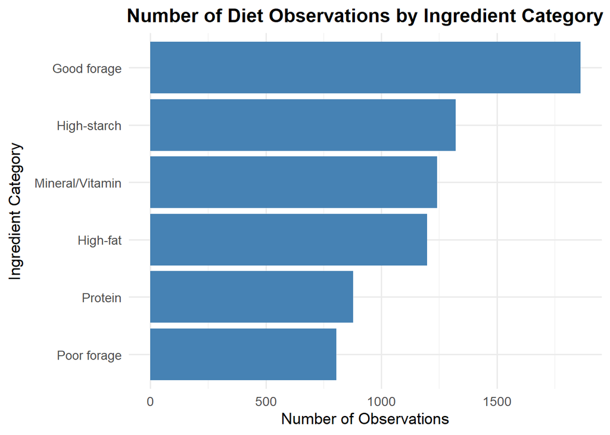

```
## # A tibble: 6 × 2
##   Ingredient_Category N_Obs
##   <chr>               <int>
## 1 Good forage          1862
## 2 High-starch          1322
## 3 Mineral/Vitamin      1241
## 4 High-fat             1199
## 5 Protein               878
## 6 Poor forage           805
```

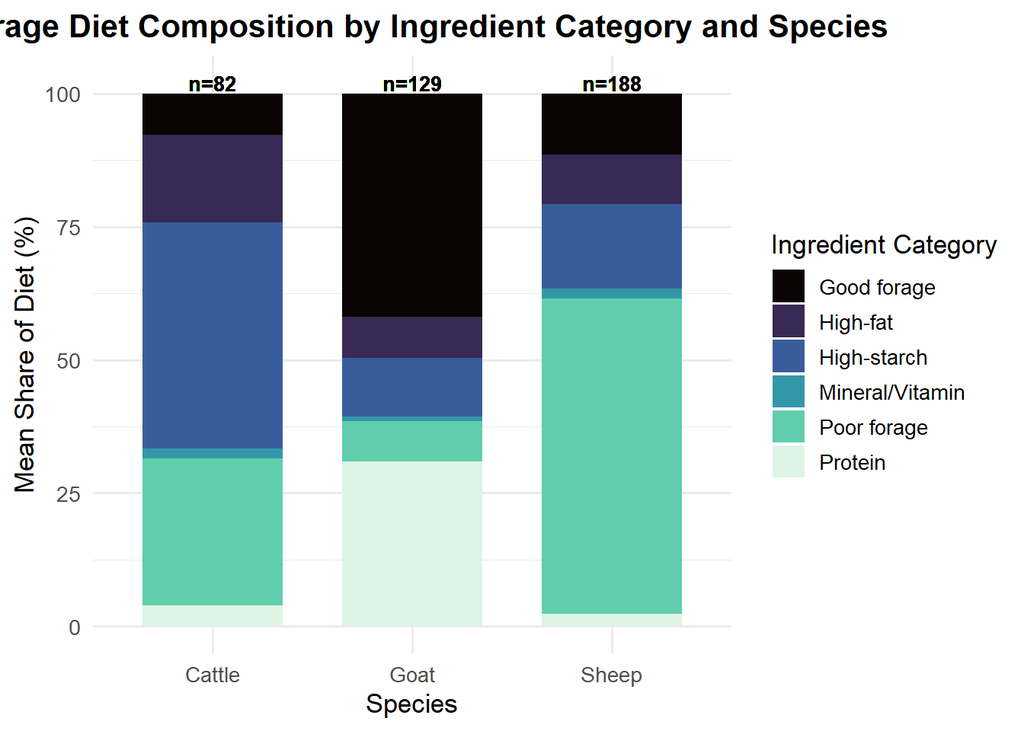

| Species | Ingredient Category | Mean_Share | N_obs | Mean Share (%) |
| --- | --- | --- | --- | --- |
| Cattle | Good forage | 39.71962399751579 | 992 | 7.714167832658178 |
| Cattle | High-fat | 84.99979147959284 | 578 | 16.50827956617962 |
| Cattle | High-starch | 218.3432172538749 | 1094 | 42.40564369703706 |
| Cattle | Mineral/Vitamin | 9.40464594745229 | 298 | 1.826528298704767 |
| Cattle | Poor forage | 142.2521858862904 | 570 | 27.62758369912981 |
| Cattle | Protein | 20.17241825588723 | 150 | 3.917796906290566 |
| Goat | Good forage | 201.1904241287924 | 3397 | 41.90976942538633 |
| Goat | High-fat | 37.43364041362621 | 2127 | 7.797762966509802 |
| Goat | High-starch | 52.8309394720159 | 1956 | 11.00515842832235 |
| Goat | Mineral/Vitamin | 3.539986740202694 | 1410 | 0.7374109811302298 |

[output cut: 8 more lines]

[figure not shown]

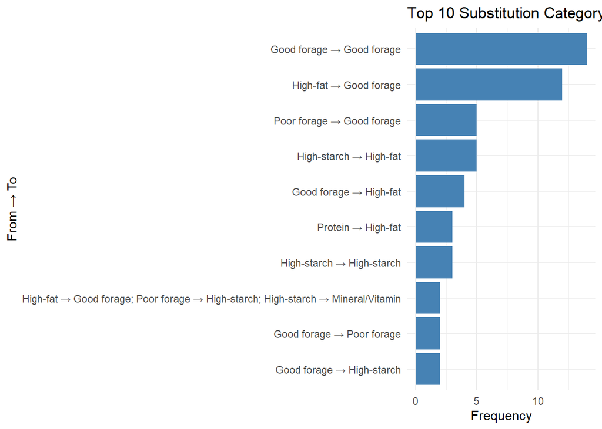

| From → To | Frequency |
| --- | --- |
| Good forage → Good forage | 14 |
| High-fat → Good forage | 12 |
| High-starch → High-fat | 5 |
| Poor forage → Good forage | 5 |
| Good forage → High-fat | 4 |
| High-starch → High-starch | 3 |
| Protein → High-fat | 3 |
| Good forage → High-starch | 2 |
| Good forage → Poor forage | 2 |
| High-fat → Good forage; Poor forage → High-starch; High-starch → Mineral/Vitamin | 2 |

## Relationship between yield and methane emissions

This section explores the fundamental link between **animal productivity** and **methane output** across livestock species.  
By plotting annual CH₄ emissions against both **meat yield** and **milk yield**, the figures assess whether higher-producing animals tend to emit more methane in absolute terms, and whether the expected scaling between feed intake, energy use, and CH₄ production holds true.  
The subsequent boxplots summarize the overall distribution of annual methane emissions by species—first across all livestock, then focusing specifically on **goats vs. sheep** to highlight small-ruminant contrasts.  
Finally, emission intensity (CH₄ per kg of product) is computed from harmonized yield data to provide a normalized view of efficiency.  
Together, these diagnostics ensure that yield–emission relationships are internally consistent and biologically plausible before interpreting practice- and diet-level mitigation effects.

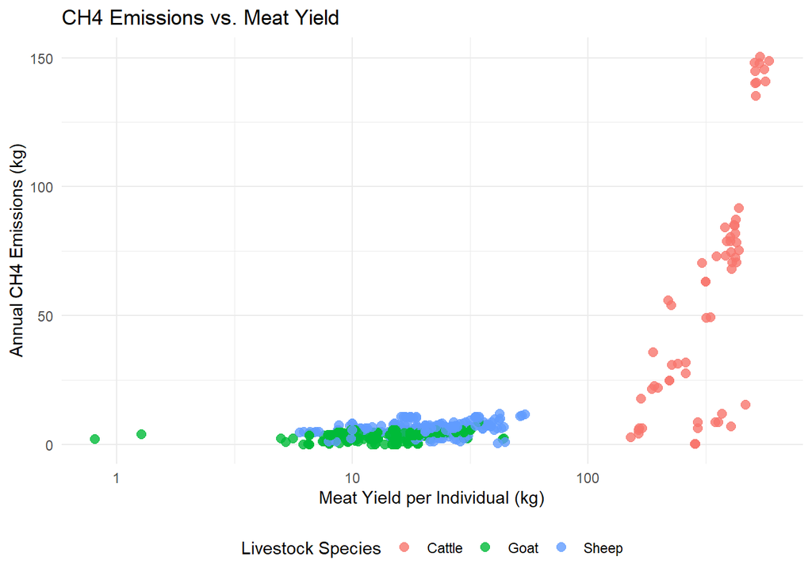

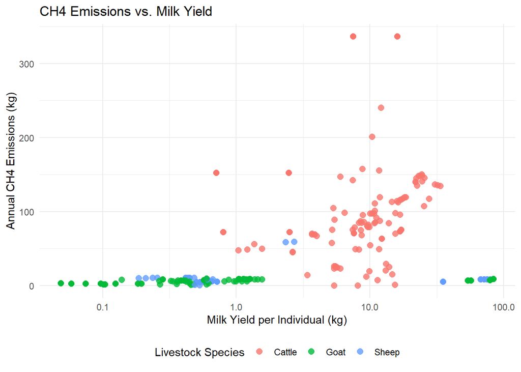

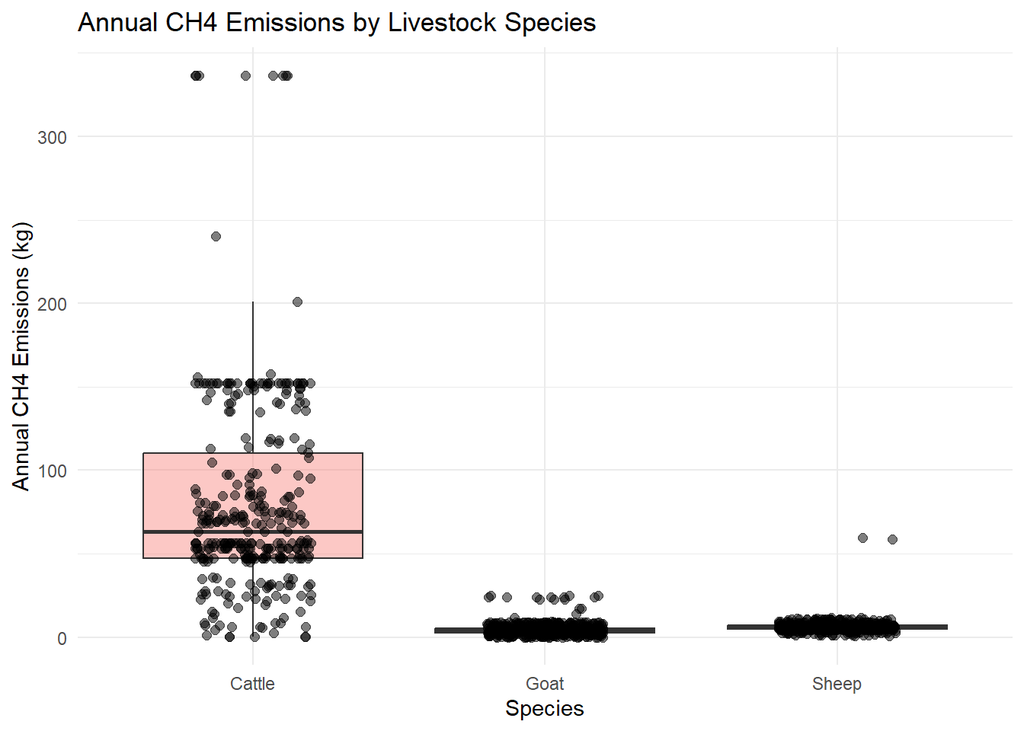

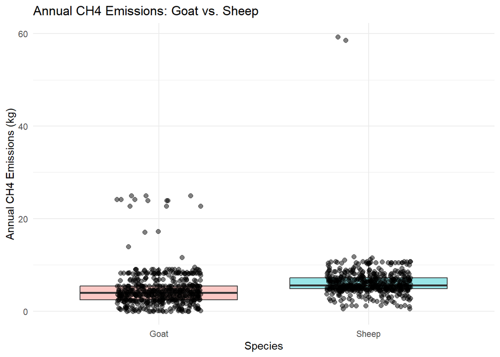

| P.Product | Mean_CH4 | Median_CH4 | Var_CH4 | N_Obs |
| --- | --- | --- | --- | --- |
| Cattle | 81.07973039409814 | 63.1931727649189 | 3659.292211036943 | 322 |
| Sheep | 6.207859413547572 | 5.58290066415748 | 15.27134602888664 | 513 |
| Goat | 4.661885318312698 | 3.98244252038457 | 15.21875222371582 | 530 |

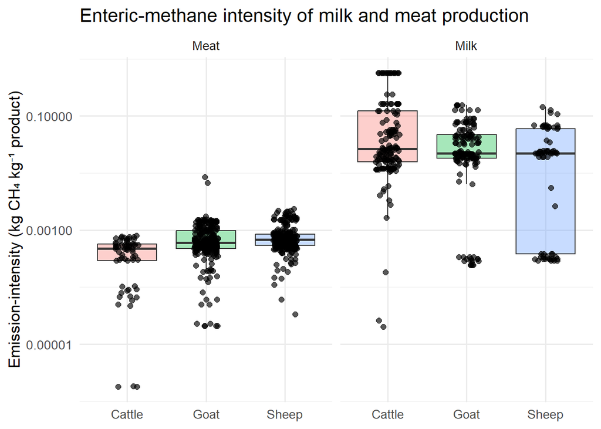

| Species | Product | Mean (kg CH₄ kg⁻¹) | Median (kg CH₄ kg⁻¹) | Variance | N |
| --- | --- | --- | --- | --- | --- |
| Sheep | Meat | 0.0007793365691567664 | 0.0006755004301985909 | 1.718923270291662e-07 | 281 |
| Goat | Meat | 0.0007544155262104439 | 0.0005994395795778458 | 5.01130379465232e-07 | 271 |
| Cattle | Meat | 0.0004146187988978676 | 0.0004710977757813029 | 5.840330271048034e-08 | 61 |
| Cattle | Milk | 0.1209442380597539 | 0.02627985162235069 | 0.03669091223829422 | 152 |
| Goat | Milk | 0.0380277845031213 | 0.02198221147585686 | 0.001263425520523774 | 143 |
| Sheep | Milk | 0.0307224064044559 | 0.02214866919292733 | 0.001128050114495013 | 66 |

## Emission in function of the highest cat in each diet

This analysis examines how enteric methane (CH₄) emissions vary according to the **dominant ingredient category** in each diet.  
By identifying the feed category contributing the largest share of dry matter (e.g., *high-starch*, *protein*, *good forage*), each diet is linked to a primary nutritional “driver.”  
The purpose of these plots is to test whether diets dominated by different ingredient types are systematically associated with higher or lower methane outputs across products (milk, meat, etc.).  
The resulting boxplots compare **annual CH₄ emissions (kg animal⁻¹ yr⁻¹)** across dominant categories within each livestock product, helping visualize whether certain feed bases—such as energy-rich concentrates or improved forages—tend to correspond to lower methane emissions.  
This provides an intuitive, data-driven way to explore diet-level variability before applying more formal emission intensity normalization.

```
## # A tibble: 17 × 6
## # Groups:   P.Product [3]
##    P.Product dom_category    n_diets mean_CH4 median_CH4 sd_CH4
##    <chr>     <chr>             <int>    <dbl>      <dbl>  <dbl>
##  1 Cattle    Good forage          58    59.5       74.0   36.2
##  2 Cattle    High-starch          40    77.0       70.4   50.2
##  3 Cattle    High-fat             18    77.7       63.9   77.2
##  4 Cattle    Poor forage          18    34.0       35.0   18.1
##  5 Cattle    Protein               3    55.2       63.2   20.5
##  6 Goat      Good forage         129     5.46       3.35   8.95
##  7 Goat      Poor forage          58     4.43       3.07   8.65
##  8 Goat      High-fat             36     5.37       4.93   3.70
##  9 Goat      High-starch          29     6.49       4.06  11.5
## 10 Goat      Protein               6     2.22       1.78   1.30
## 11 Goat      Mineral/Vitamin       3     0          0      0
## 12 Sheep     Good forage         152     5.74       5.58   2.67
## 13 Sheep     Poor forage          86     5.48       4.78   8.76
## 14 Sheep     High-fat             65     6.31       6.32   2.49
## 15 Sheep     High-starch          59     6.92       7.12   2.96
## 16 Sheep     Protein              15     7.61       8.53   2.86
## 17 Sheep     Mineral/Vitamin       2     1.80       1.80   2.54
```

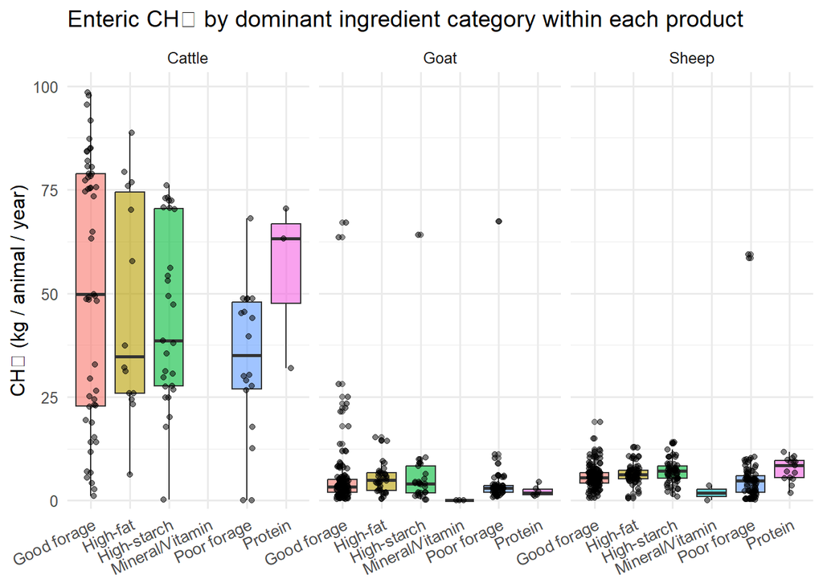

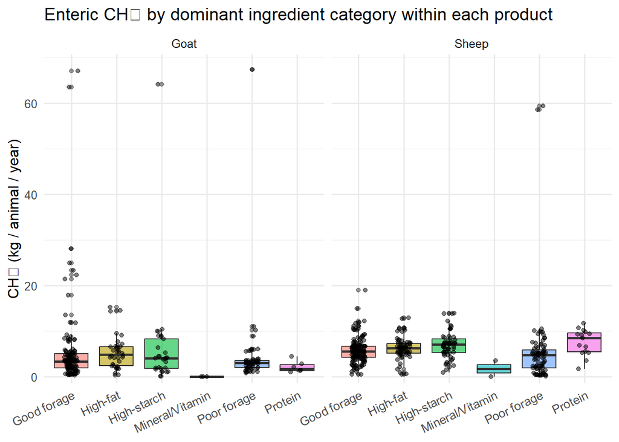

```r
plot_df <- dom %>%
  left_join(ch4, by = "A.Level.Name") %>%
  filter(CH4_kg_year < 100)%>%
  filter(P.Product!="Cattle")# optional outlier trim; remove if not desired
# get common y-limits across all products (after any filtering you apply)
y_lims <- range(plot_df$CH4_kg_year, na.rm = TRUE)

ggplot(plot_df, aes(x = dom_category, y = CH4_kg_year, fill = dom_category)) +
  geom_boxplot(alpha = 0.6, outlier.alpha = 0.5) +
  geom_jitter(width = 0.15, height = 0, alpha = 0.5, size = 1.4, show.legend = FALSE) +
  facet_wrap(~ P.Product, scales = "fixed") +              # <- same y for all facets
  scale_y_continuous(limits = y_lims, expand = expansion(mult = c(0.02, 0.05))) +
  labs(x = NULL, y = "CH₄ (kg / animal / year)",
       title = "Enteric CH₄ by dominant ingredient category within each product") +
  theme_minimal(base_size = 12) +
  theme(legend.position = "none",
        axis.text.x = element_text(angle = 25, hjust = 1))
```

## Emission intensity and practice-level contrasts

Together, these figures provide an empirical overview of how different feeding interventions influence methane efficiency, serving as a foundation for interpreting diet-level levers in subsequent analyses.

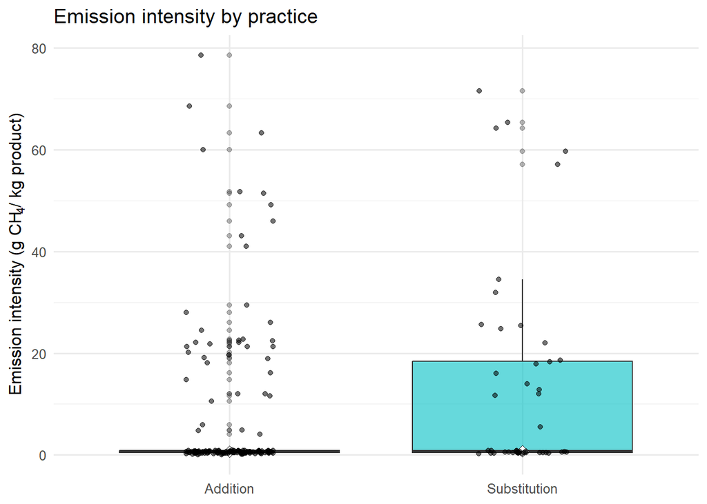

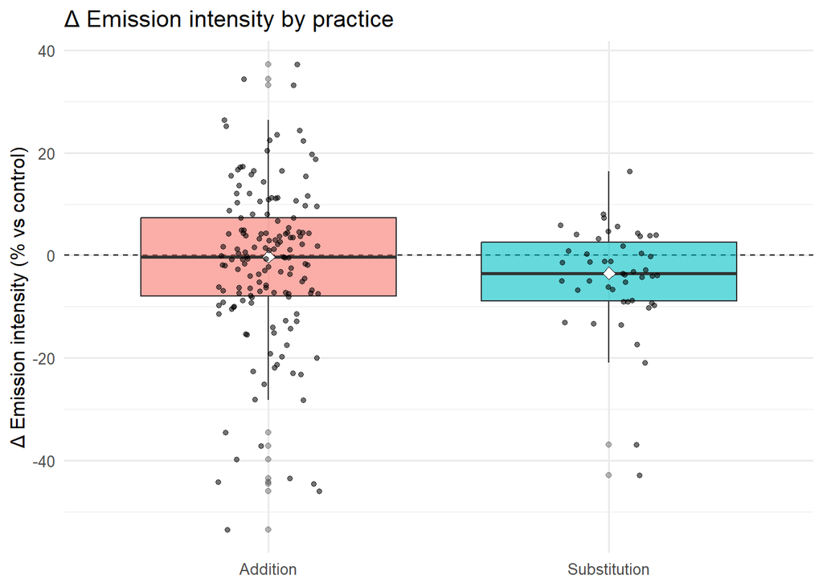

| Practice | Mean (g CH₄/kg) | Median (g CH₄/kg) | Variance | N |
| --- | --- | --- | --- | --- |
| Substitution | 13.2597207463001 | 0.7431935300334216 | 405.1175567700419 | 47 |
| Addition | 6.903616240383923 | 0.6579196675743207 | 213.7293650613706 | 162 |

| Practice | Mean ΔEI (%) | Median ΔEI (%) | Variance | N |
| --- | --- | --- | --- | --- |
| Addition | -1.514159244153456 | -0.2808032867968269 | 248.0597675367372 | 151 |
| Substitution | -4.350391022486189 | -3.510797185099646 | 108.4290446794007 | 47 |

## Emission intensity and yield changes by subpractice

This section disaggregates emission intensity results by **subpractice**, representing the dominant dietary lever applied within each experiment (e.g., *lipid addition*, *protein supplement*, *forage substitution*).  
While the previous section examined overall practice effects (*Addition* vs. *Substitution*), these plots reveal which specific feed modifications drive the largest differences in methane outcomes.

- **Emission intensity by subpractice** — compares absolute CH₄ emission intensity (g CH₄ kg⁻¹ product) across all subpractices, reordered by their median values to highlight which dietary levers are most emission-efficient.
- **ΔEI (% vs. control)** — shows the percent change in emission intensity relative to each study’s control diet, with negative values indicating mitigation potential.
- **ΔEI for Additions and Substitutions separately** — isolates the effects of additive vs. replacement strategies to distinguish how these intervention types alter emission responses.
- **ΔYield (% vs. control)** — evaluates whether changes in emission intensity occur alongside productivity gains or losses, ensuring that apparent CH₄ reductions are not driven by yield depression.

Together, these figures provide a fine-grained understanding of **which feed interventions consistently reduce methane intensity**, helping identify robust mitigation strategies within and across livestock products.

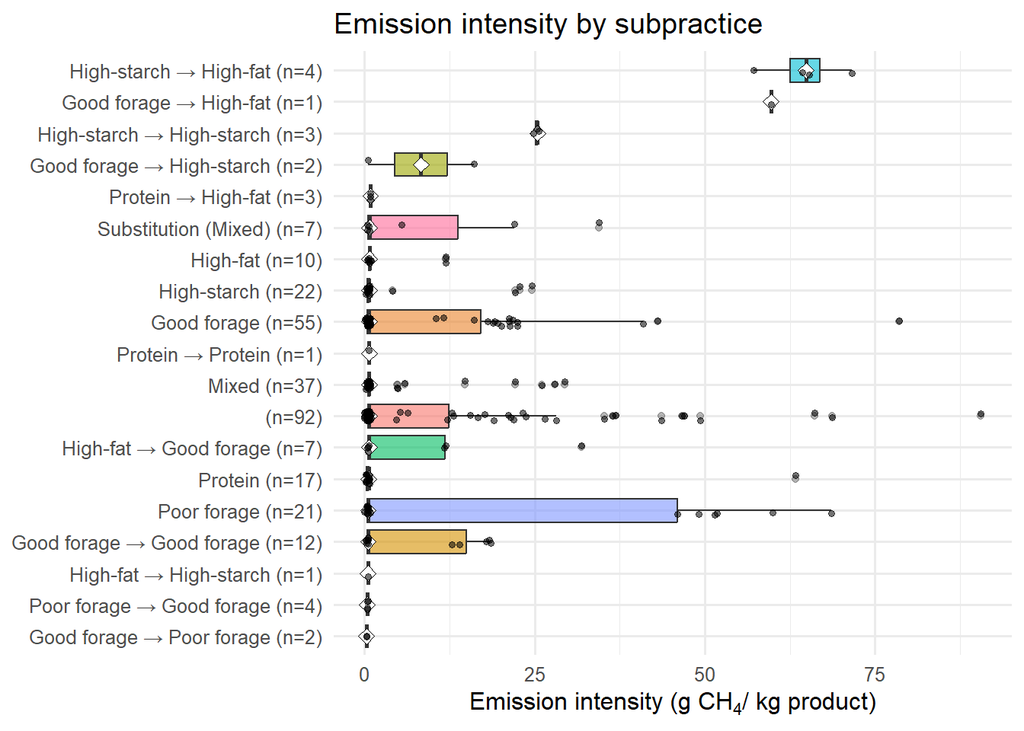

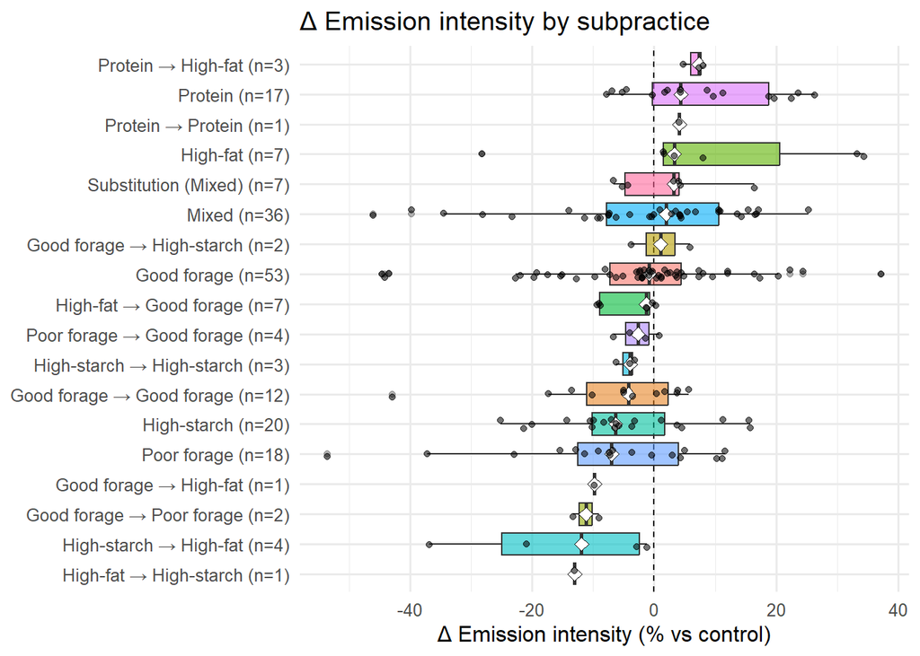

```r
# Summarise ΔEI (%) by subpractice
delta_sub_tbl <- final_with_deltas %>%
  group_by(Subpractice) %>%
  summarise(
    Mean_Delta   = mean(Delta_EI_pct, na.rm = TRUE),
    Median_Delta = median(Delta_EI_pct, na.rm = TRUE),
    Var_Delta    = var(Delta_EI_pct, na.rm = TRUE),
    N_Obs        = n(),
    .groups = "drop"
  ) %>%
  arrange(desc(Mean_Delta))

# Pretty interactive table (for knitting)
datatable(
  delta_sub_tbl,
  rownames = FALSE,
  caption = htmltools::tags$caption(
    style = "caption-side: top; text-align: center; font-weight: bold;",
    "Δ Emission Intensity (% vs Control) by Subpractice"
  ),
  colnames = c(
    "Subpractice" = "Subpractice",
    "Mean ΔEI (%)" = "Mean_Delta",
    "Median ΔEI (%)" = "Median_Delta",
    "Variance" = "Var_Delta",
    "N" = "N_Obs"
  ),
  options = list(
    pageLength = 10,
    dom = 't',  # simple table, no search box
    columnDefs = list(list(className = 'dt-center', targets = "_all"))
  )
)
```

| Subpractice | Mean ΔEI (%) | Median ΔEI (%) | Variance | N |
| --- | --- | --- | --- | --- |
| High-fat | 7.691824868337148 | 3.315869624598911 | 457.9021776207206 | 7 |
| Protein | 7.574934683919257 | 4.368262800628719 | 126.369708432123 | 17 |
| Protein → High-fat | 6.730995122622963 | 7.349831373629989 | 3.04407953526006 | 3 |
| Protein → Protein | 4.1572082065648 | 4.1572082065648 |  | 1 |
| Substitution (Mixed) | 1.684090195525904 | 3.261122634007751 | 64.3750043534113 | 7 |
| Good forage → High-starch | 1.071409698626075 | 1.071409698626075 | 45.69160325509917 | 2 |
| Mixed | -1.680134564903669 | 1.959325572600623 | 270.264073840654 | 36 |
| Good forage | -2.050685839324993 | -0.818376472774851 | 244.8872474202819 | 53 |
| Poor forage → Good forage | -2.793091147658455 | -2.667118460046969 | 10.56203321418416 | 4 |
| High-fat → Good forage | -4.203031350779525 | -1.290950044792216 | 20.63077880162477 | 7 |

[output cut: 8 more lines]

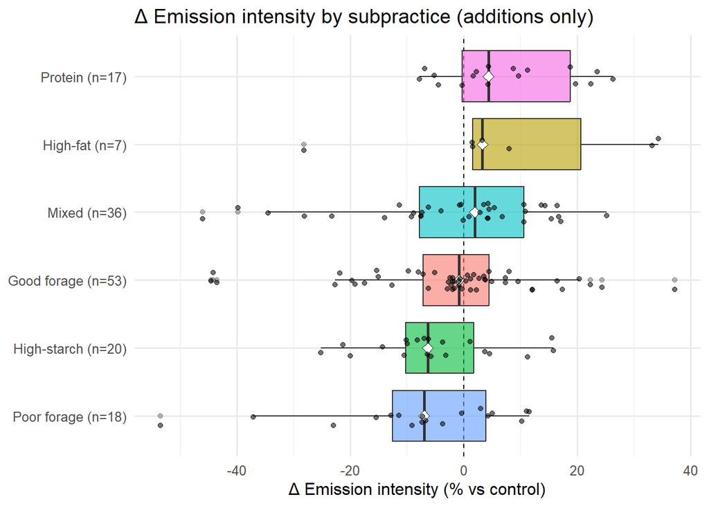

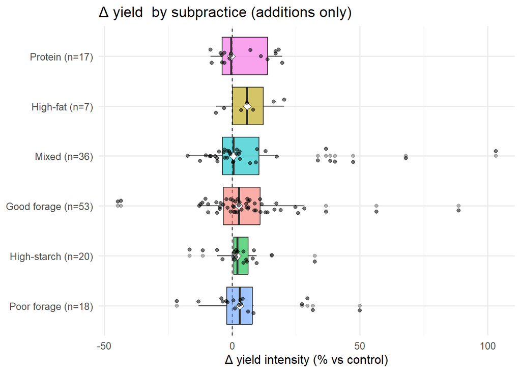

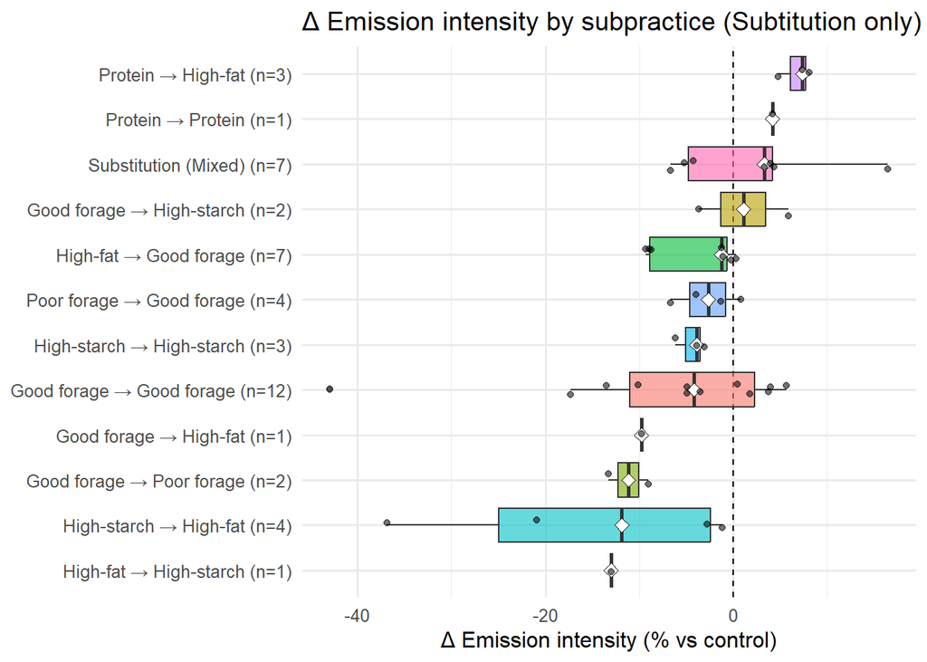

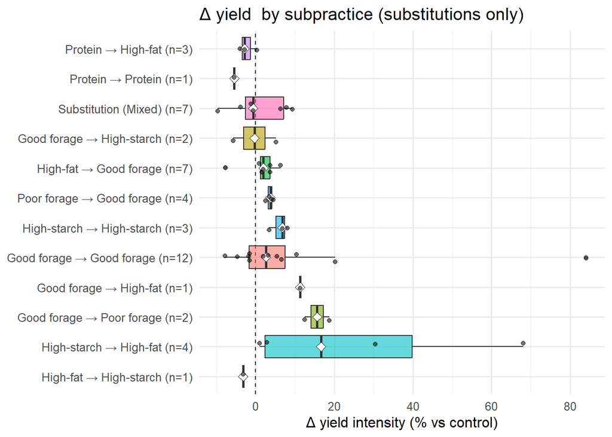

```
## # A tibble: 3 × 2
##   P.Product n_papers
##   <chr>        <int>
## 1 Sheep           26
## 2 Goat            22
## 3 Cattle          20
```

## Spatial distribution of ERA feeding trials

This map summarizes the **geographical coverage** of the studies included in the emission-intensity analysis.  
Each point represents a study site from the ERA meta-dataset where methane emissions and yield data were available, while the shaded countries indicate the **number of distinct sites** contributing data within their borders.  
By visualizing the spatial footprint of the dataset, this figure helps assess **regional representativeness** and identify data clusters or geographic gaps across Africa.  
Such spatial context is critical for interpreting emission responses, as feed resources, production systems, and experimental conditions vary considerably among regions.  
Together, these patterns illustrate the extent to which the ERA database captures continental diversity in livestock feeding practices and methane emission measurements.

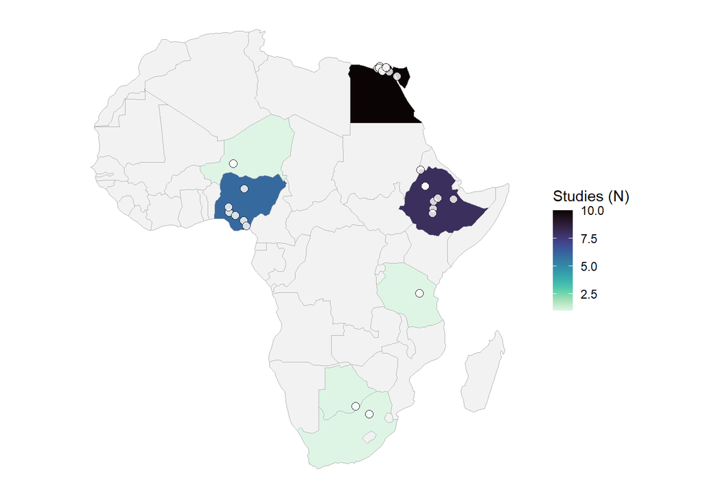

## Emission and yield responses separated by livestock group

- **Emission intensity by subpractice** — compares absolute CH₄ intensity (g CH₄ kg⁻¹ product) among subpractices, now stratified by animal group, highlighting baseline efficiency differences between cattle and small ruminants.
- **ΔEI (% vs. control)** — quantifies relative changes in methane intensity due to feeding interventions, showing how each subpractice performs within and across species groups.
- **Addition vs. Substitution effects** — examines the direction and magnitude of ΔEI for additive and replacement strategies separately, clarifying whether certain interventions reduce emissions more effectively in specific ruminant types.
- **ΔYield (% vs. control)** — evaluates the production response accompanying each emission change, ensuring that mitigation patterns are not confounded by yield reductions.

Together, these comparisons contextualize diet-mitigation outcomes by species, providing insight into whether feed-based CH₄ reduction strategies can be generalized across African livestock systems or require species-specific adaptation.

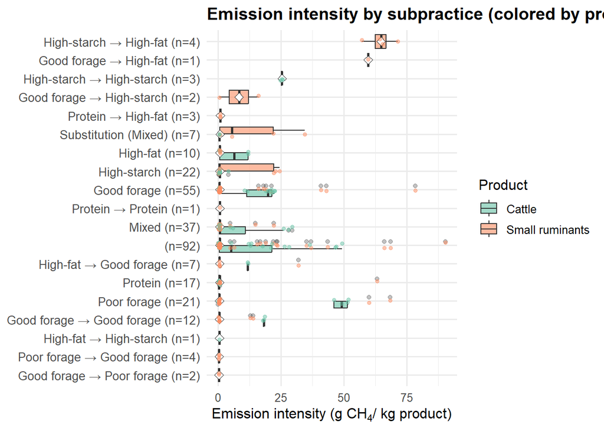

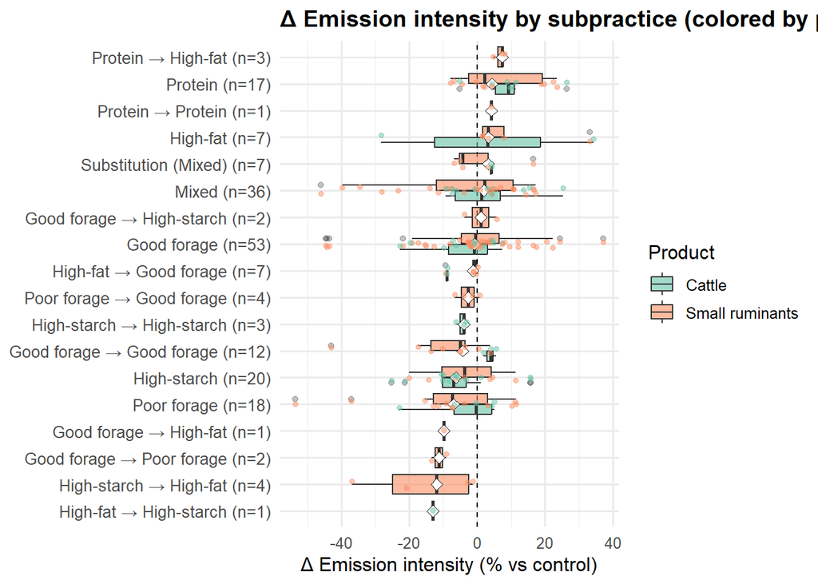

| Subpractice | Species Group | Mean ΔEI (%) | Median ΔEI (%) | Variance | N |
| --- | --- | --- | --- | --- | --- |
| Good forage | Small ruminants | -1.433837153187791 | -0.5230236981204284 | 284.8779225820393 | 42 |
| Good forage | Cattle | -4.4059262773034 | -0.8448231822085761 | 97.71422105967285 | 11 |
| Good forage → Good forage | Cattle | 3.778179517266689 | 3.91924374472401 | 3.720348228275137 | 3 |
| Good forage → Good forage | Small ruminants | -10.35524303184227 | -4.945543884457015 | 192.6965279696302 | 9 |
| Good forage → High-fat | Small ruminants | -9.791369642368108 | -9.791369642368108 |  | 1 |
| Good forage → High-starch | Small ruminants | 1.071409698626075 | 1.071409698626075 | 45.69160325509917 | 2 |
| Good forage → Poor forage | Small ruminants | -11.16888839430498 | -11.16888839430498 | 9.223252928364692 | 2 |
| High-fat | Small ruminants | 9.53955835772223 | 3.315869624598911 | 182.8121031733011 | 5 |
| High-fat | Cattle | 3.072491144874444 | 3.072491144874444 | 1956.417569694703 | 2 |
| High-fat → Good forage | Small ruminants | -2.330040382237293 | -1.115221059736704 | 15.59159124979116 | 5 |

[output cut: 17 more lines]

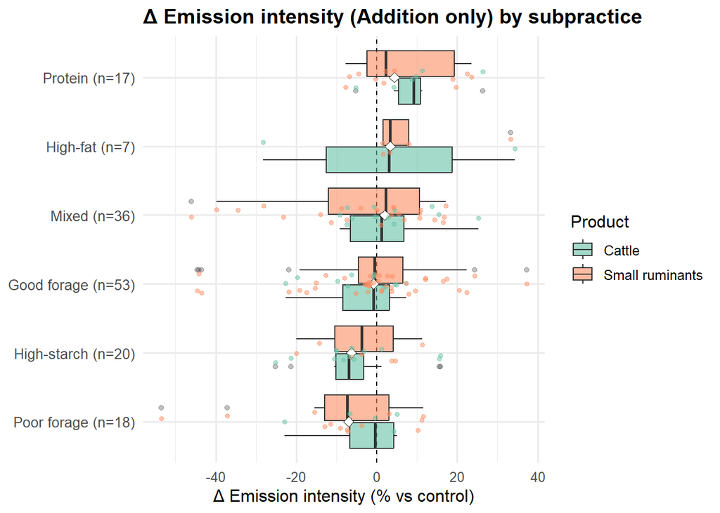

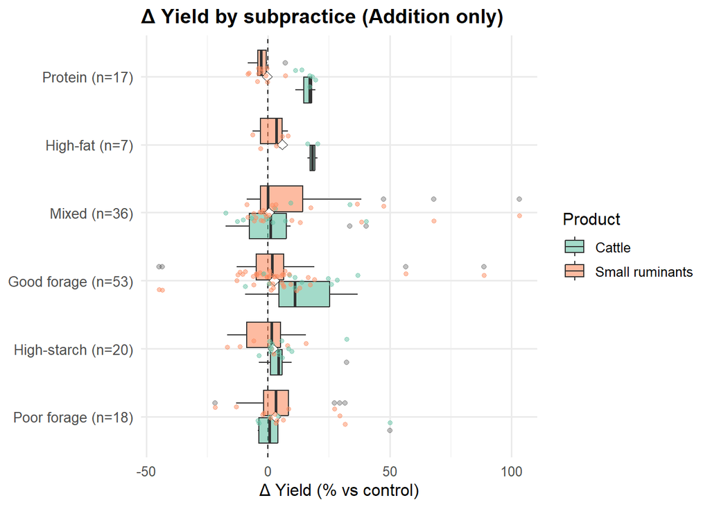

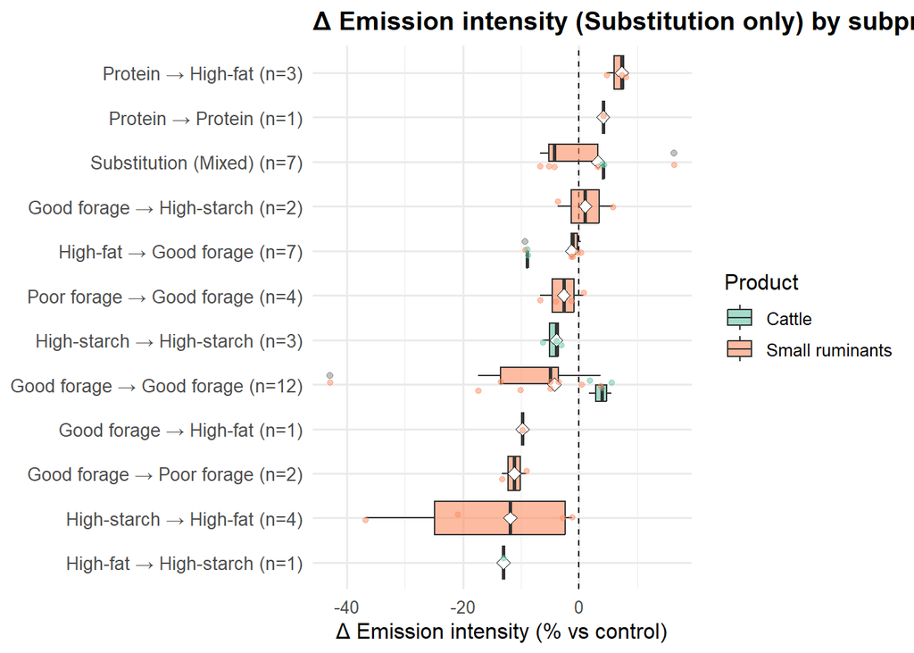

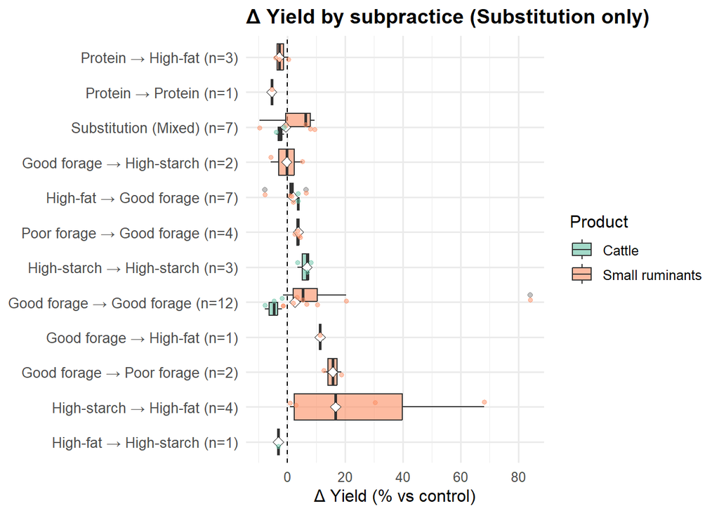

## Diet-shift analysis at the paired-diet level

This section extends the emission-intensity comparison to **paired diet shifts**, where both control and treatment diets are explicitly defined within the same experiment.  
Unlike the earlier practice-level summaries, which aggregate all “Additions” or “Substitutions,” this analysis focuses on **direct A–B diet pairs** to capture how complete reformulation of rations influences methane efficiency.  
The workflow integrates emission, yield, and diet-classification data to calculate emission intensity (EI) for each diet arm and then compute **ΔEI (%)** — the relative change between the two paired diets.

- **Emission intensity by diet shift vs. no change** — compares absolute CH₄ intensity (g CH₄ kg⁻¹ product) between diets classified as “shifted” and those with no modification, revealing whether reformulated diets systematically reduce emissions.
- **ΔEI (% vs. paired arm)** — quantifies the relative gain or loss in emission efficiency between paired diets, with negative values indicating mitigation effects.

Together, these figures provide a diet-level validation of ERA’s classification logic, showing whether observed shifts in ingredient composition correspond to measurable reductions in enteric methane intensity across livestock products.

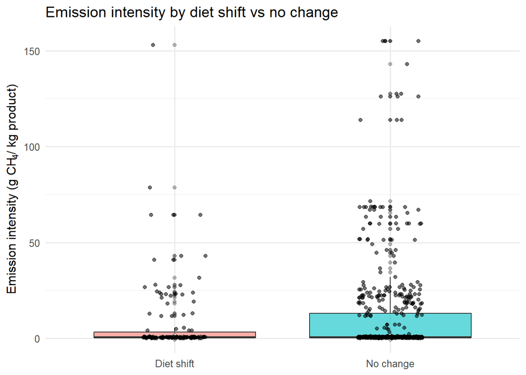

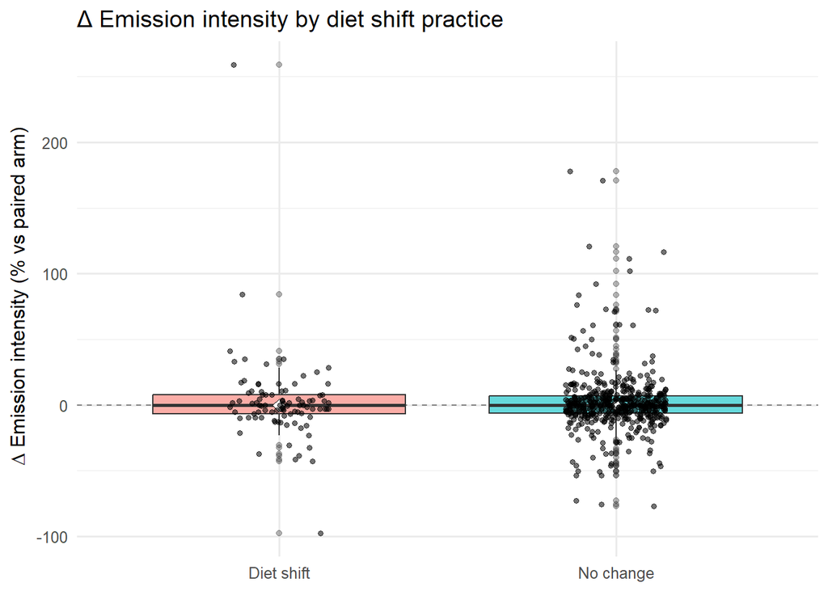

## Subpractice-level effects within diet shifts

This section disaggregates the **diet shift** category to explore how specific reformulation strategies—such as increasing concentrate proportion, improving forage quality, or balancing nutrients—affect methane emission intensity and productivity outcomes.  
Each *subpractice* represents a distinct dietary change implemented between paired diets (A vs. B) within the same experiment.

- **Emission intensity by subpractice** — shows the absolute CH₄ intensity (g CH₄ kg⁻¹ product) for each diet shift subcategory, reordered by their median values to highlight which nutritional strategies are most emission-efficient.
- **ΔEI (% vs. paired arm)** — quantifies the relative change in emission intensity between paired diets for each subpractice, with negative medians indicating consistent CH₄ mitigation effects.
- **ΔYield (% vs. paired arm)** — evaluates whether emission reductions coincide with productivity changes, identifying trade-offs or co-benefits between performance and mitigation.

Together, these plots pinpoint which types of diet shifts most effectively lower methane intensity while sustaining—or enhancing—animal productivity.

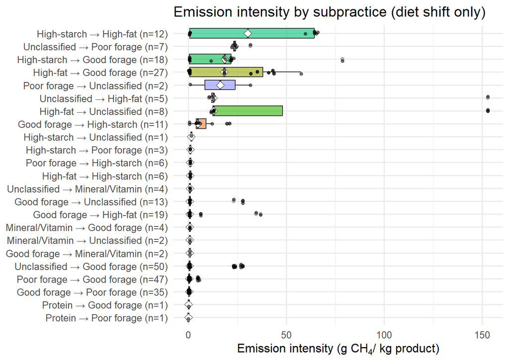

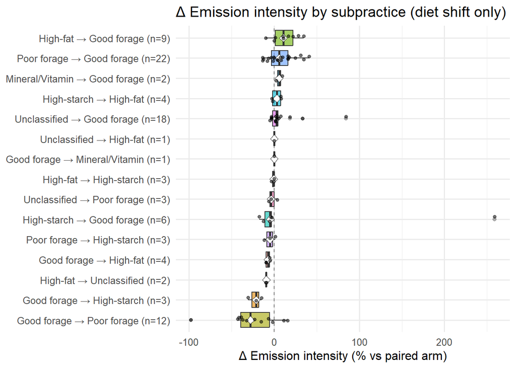

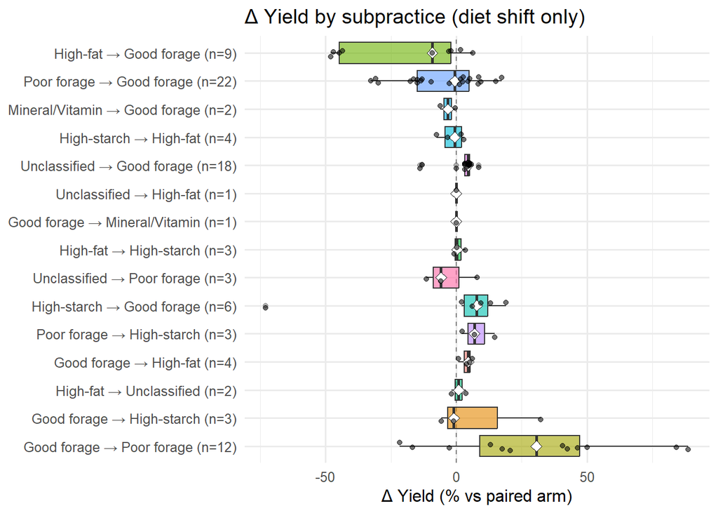